# Hypsometric Curves and Integrals of Yanze Sub-Catchments

Faustin GASHAKAMBA

1/25/2021

## I. Input Data Preparation

The first step of this process consists of delineating micro-catchments within Yanze watershed. This was done using ArcGIS’ hydrology tools and the main input data used was the DEM of Yanze watershed. The resulting map consists of 93 sub-catchments of different areas ranging from 20 to 300 Ha. Each sub-catchment was given a unique 4-character code which would serve as its ID throughout the remaining steps of the process.

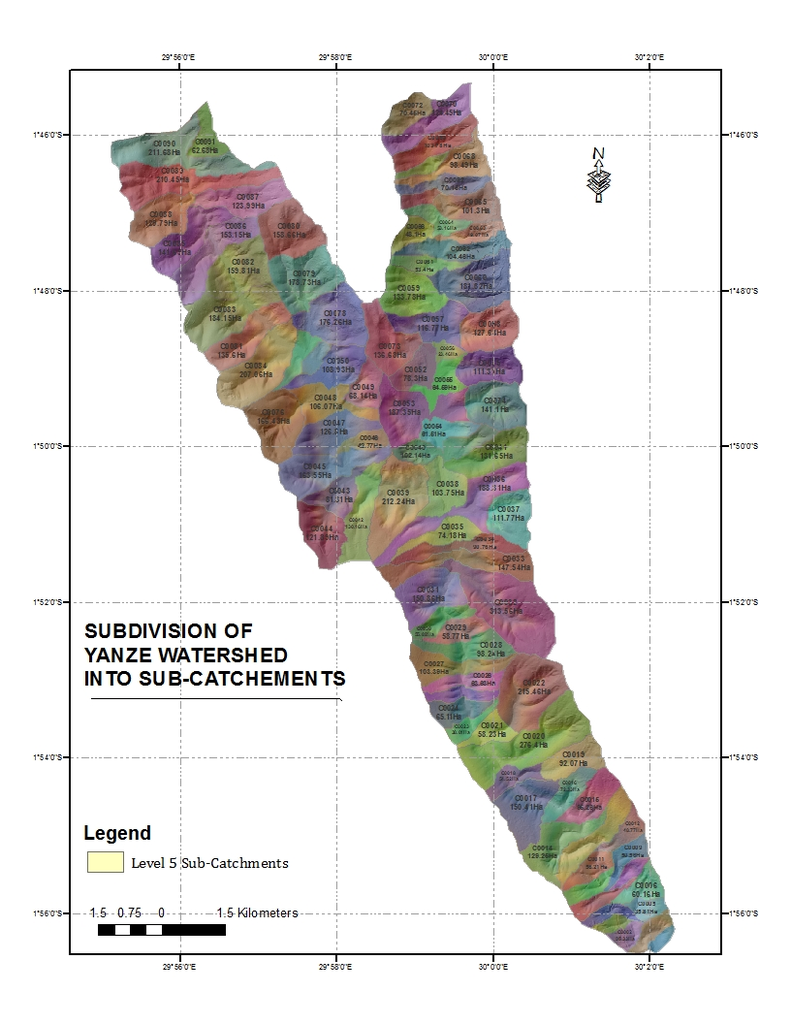

The second step is to generate required to draw an hypsometric curve for each of the 93 sub-catchments. To do this, an ArcMap model was developed to perform the six steps involved in this process in one go. These steps are:

1. Extract the DEM of the sub-catchment,
2. Reclassify the DEM into classes of equidistant elevation height,
3. Convert the reclassified DEM to vector using the ‘Value’ field,
4. Dissolve the features using the ‘Value’ field,
5. Calculate the area of each polygon, and
6. Export the table to a text file.

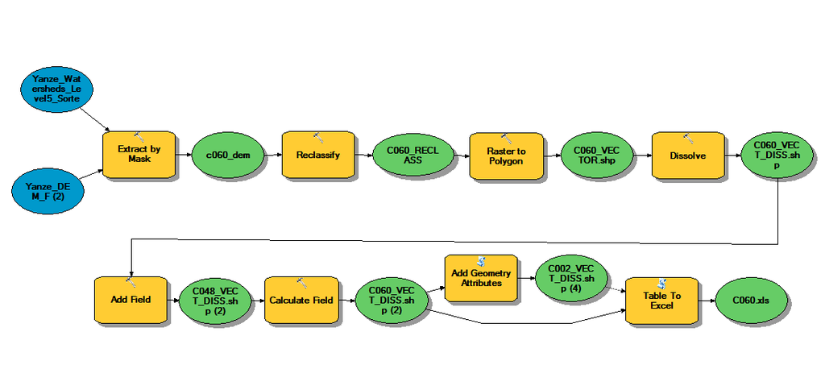

*ArcGIS Hypsometric Integral Model*

The present report outlines the results of this process. For each of the 93 sub-catchments of Yanze watershed, we will import the text file generated from ArcMap and process it to generate the hypsometric curve and integral for the sub-catchment.

## II. Used R Packages

In addition to the core R libraries, the following are the packages that we will be using to generate hypsometric curves and integrals for Yanze sub-catchments:

```r
library(dplyr) # For preprocessing data
library(ggplot2) # For drawing the hypsometric curve
library(sjPlot) # For producing the coefficient table of the fitted model
library(PolynomF) # For building a polynomial equation of the model and integrating it
library(knitr)
```

## III. Results Per Sub-Catchment

The text file exported from ArcMap will be imported into R for processing. First, the unnecessary variables will be deleted and only the elevation intervals and corresponding areas will remain. Secondly, the data will be normalized. For elevation, we first substract the minimum elevation and then divide by the range:
$$normalizedElev=\frac{elev-minElev}{maxElev-minElev}$$
For area, we divide the cumulative area at each entry by the total area of the sub-catchment:
$$normalizedArea=\frac{cumulativeSumArea}{totalArea}$$
Thirdly, we plot the data on a 2D chart showing the curve drawn from the normalized data. Finally, we fit a 3rd degree polynomial equation to the data and integrate it within the limits of 0 and 1 to produce the hypsometric integral metric of the sub-catchment.

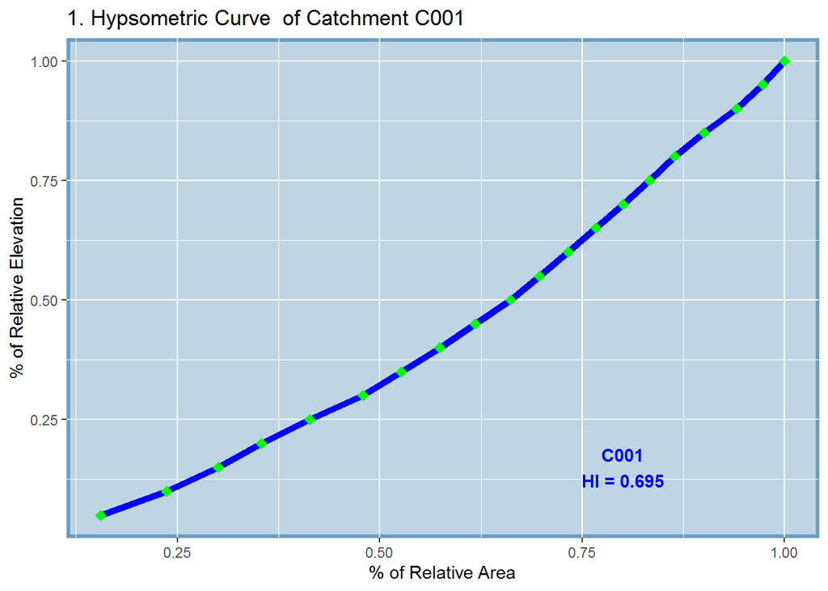

```
## [1] "The polynomial equation of sub-catchment C001 is 1.27761218182317*x + 0.171301171778388*x^2 - 0.00513597889262782*x^3"
## [1] "The hypsometric integral of sub-catchment C001 is 0.695"
```

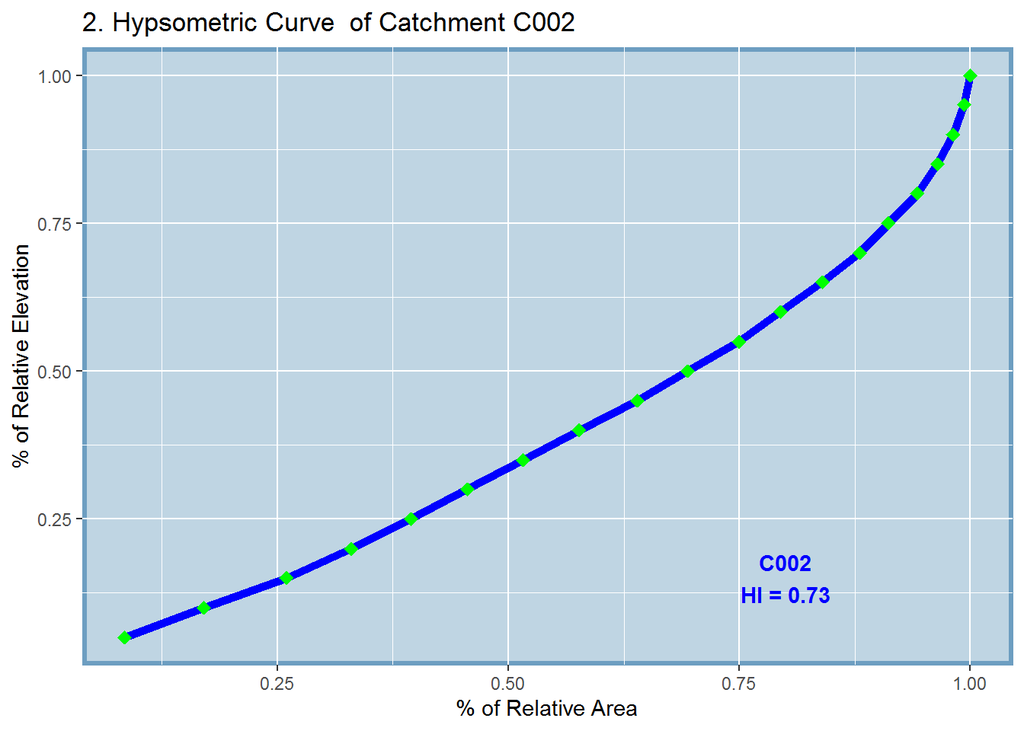

```
## [1] "The polynomial equation of sub-catchment C002 is 1.2629321551127*x + 0.222579470326882*x^2 + 0.0973174654596634*x^3"
## [1] "The hypsometric integral of sub-catchment C002 is 0.73"
```

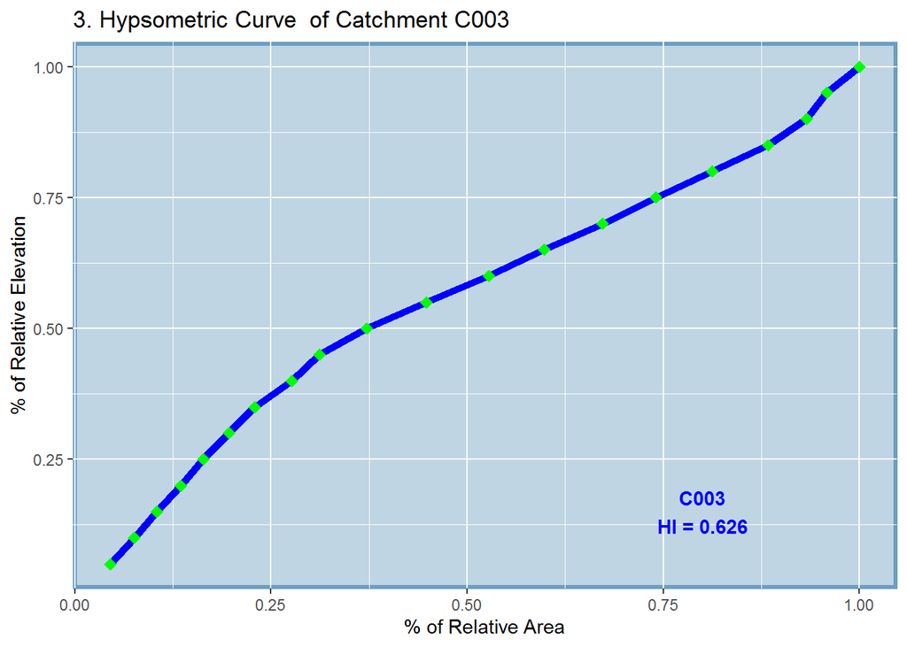

```
## [1] "The polynomial equation of sub-catchment C003 is 1.27484986253041*x - 0.135721454620197*x^2 + 0.133895850061023*x^3"
## [1] "The hypsometric integral of sub-catchment C003 is 0.626"
```

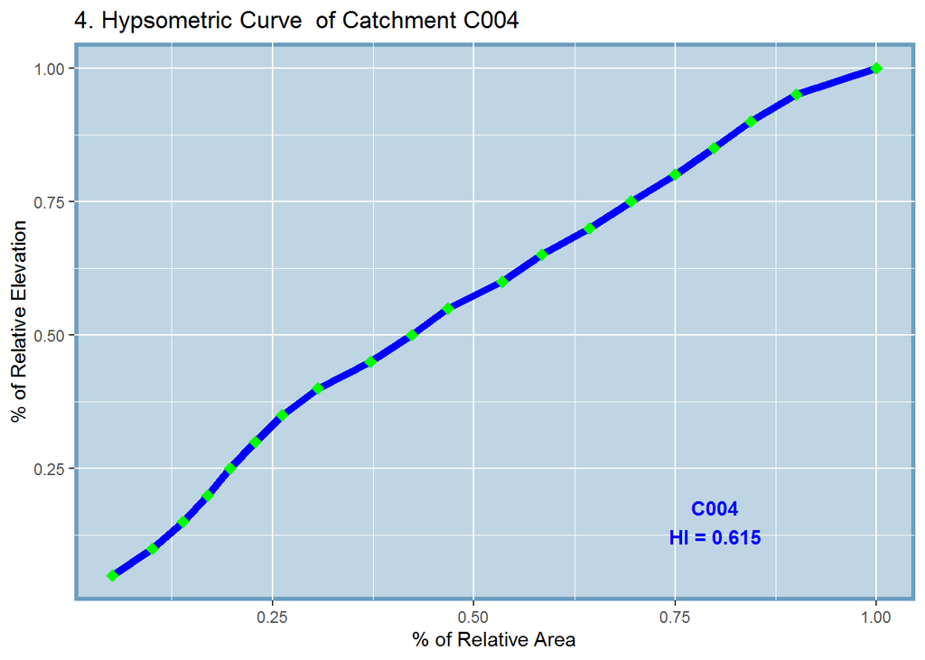

```
## [1] "The polynomial equation of sub-catchment C004 is 1.28304863090052*x - 0.10715647093451*x^2 + 0.037387222937117*x^3"
## [1] "The hypsometric integral of sub-catchment C004 is 0.615"
```

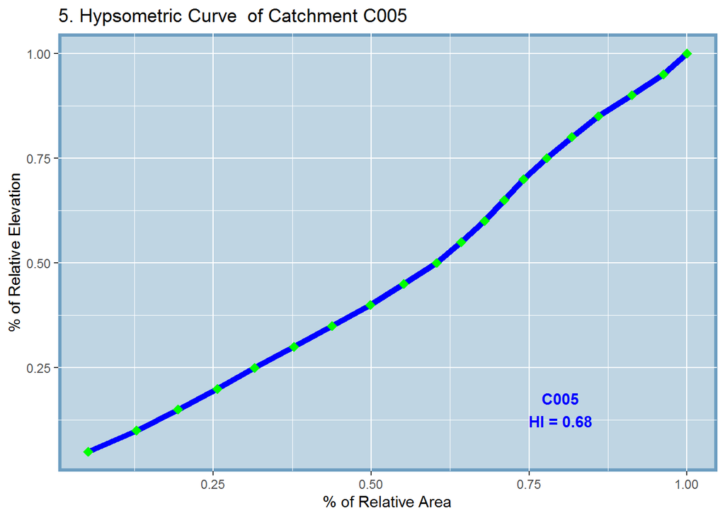

```
## [1] "The polynomial equation of sub-catchment C005 is 1.28044618582375*x + 0.136881677669805*x^2 - 0.0238119490422969*x^3"
## [1] "The hypsometric integral of sub-catchment C005 is 0.68"
```

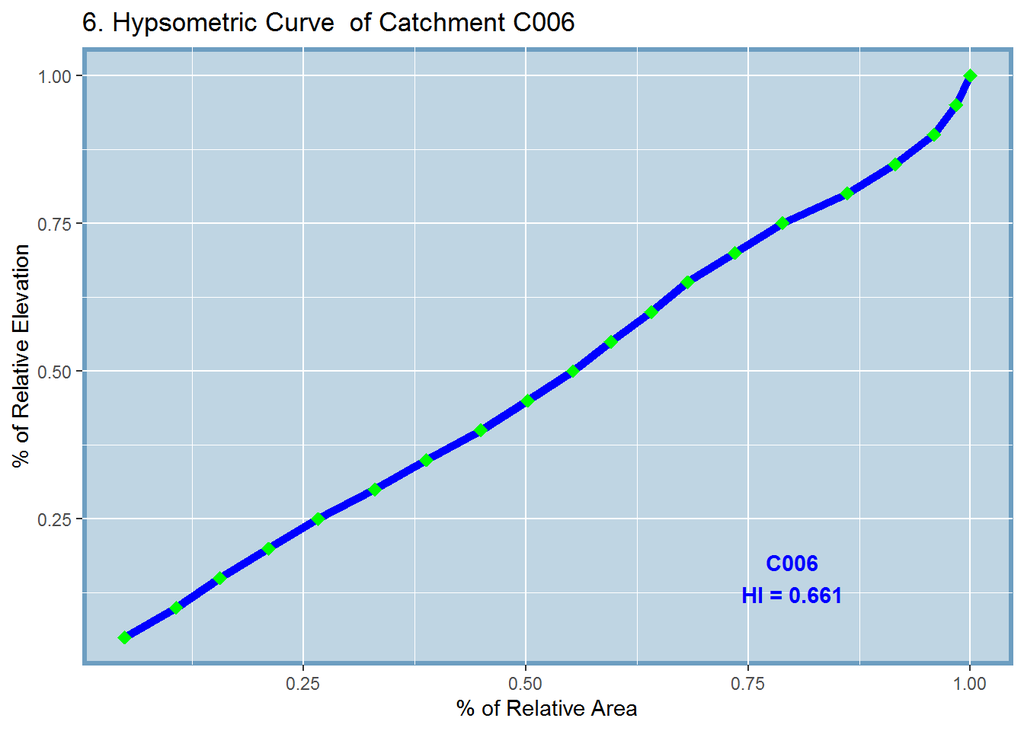

```
## [1] "The polynomial equation of sub-catchment C006 is 1.28716839730947*x + 0.0469243916539962*x^2 + 0.0081950770262518*x^3"
## [1] "The hypsometric integral of sub-catchment C006 is 0.661"
```

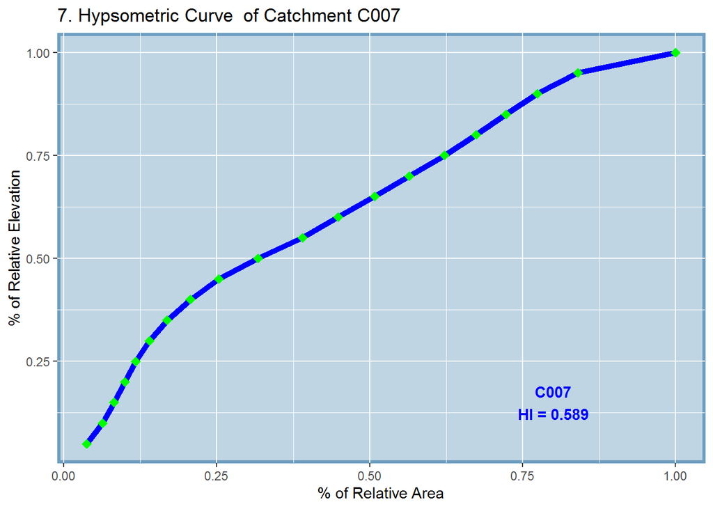

```
## [1] "The polynomial equation of sub-catchment C007 is 1.26616631131587*x - 0.193304447107123*x^2 + 0.0816663952397969*x^3"
## [1] "The hypsometric integral of sub-catchment C007 is 0.589"
```

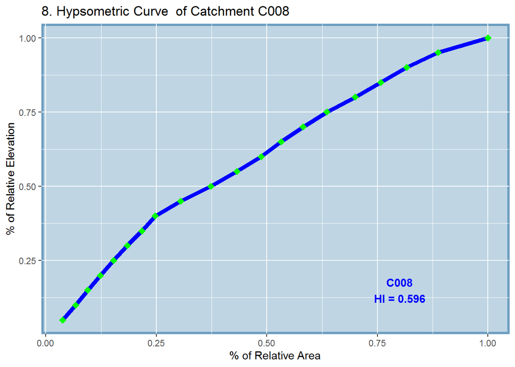

```
## [1] "The polynomial equation of sub-catchment C008 is 1.27629596035856*x - 0.163531874097781*x^2 + 0.0483456547366394*x^3"
## [1] "The hypsometric integral of sub-catchment C008 is 0.596"
```

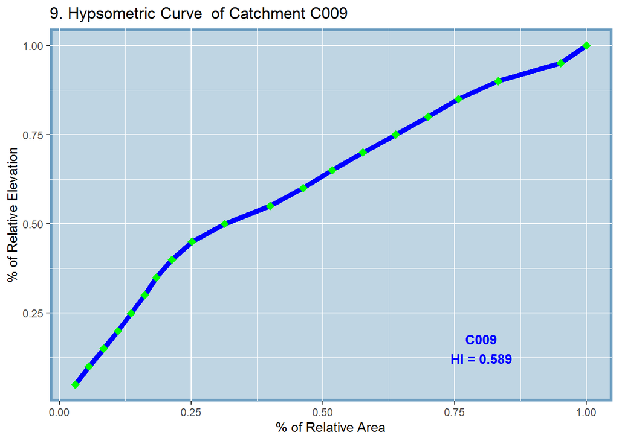

```
## [1] "The polynomial equation of sub-catchment C009 is 1.2661381101438*x - 0.206363605916641*x^2 + 0.100411423501086*x^3"
## [1] "The hypsometric integral of sub-catchment C009 is 0.589"
```

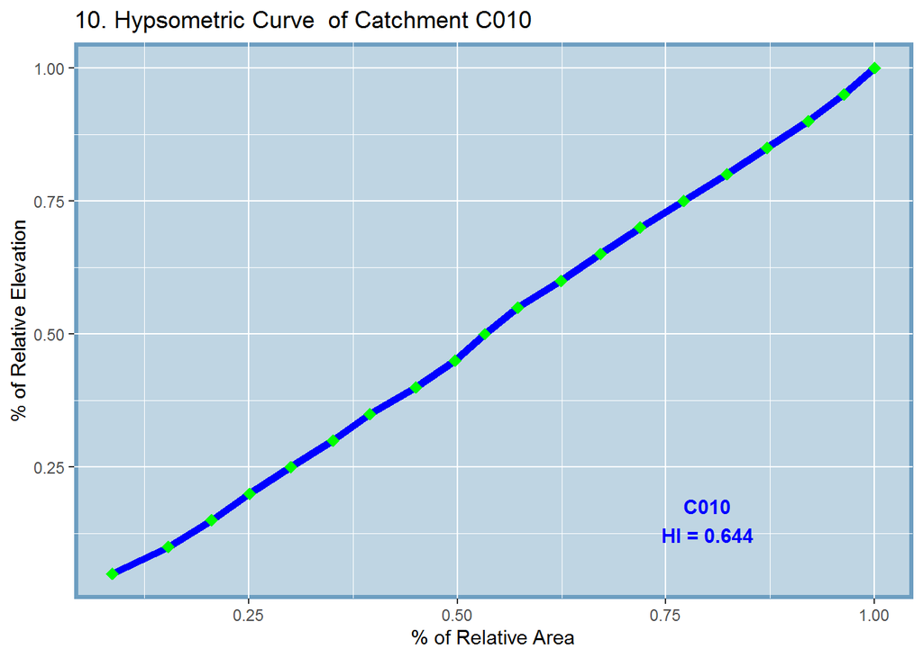

```
## [1] "The polynomial equation of sub-catchment C010 is 1.28891811902337*x + 0.011956467818896*x^2 - 0.0165834789322343*x^3"
## [1] "The hypsometric integral of sub-catchment C010 is 0.644"
```

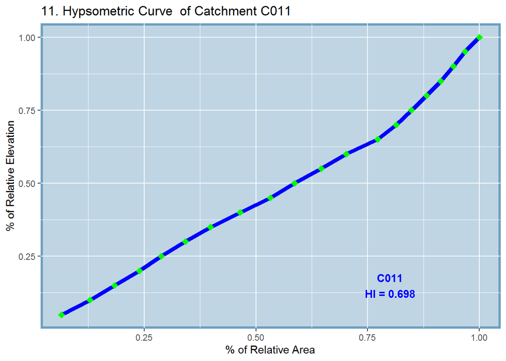

```
## [1] "The polynomial equation of sub-catchment C011 is 1.28113825577415*x + 0.106813695532629*x^2 + 0.088416263376668*x^3"
## [1] "The hypsometric integral of sub-catchment C011 is 0.698"
```

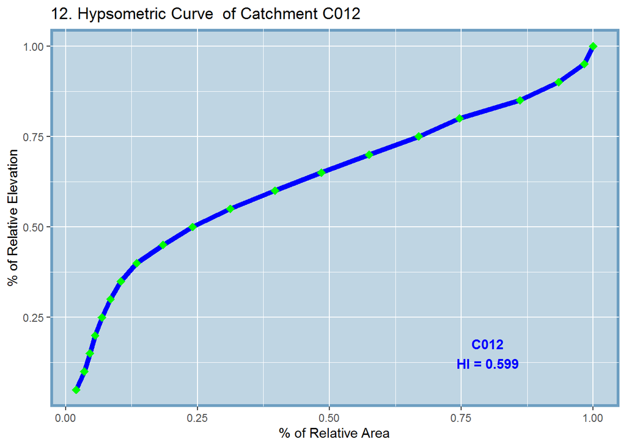

```
## [1] "The polynomial equation of sub-catchment C012 is 1.24359725085384*x - 0.229279885192258*x^2 + 0.213072855393587*x^3"
## [1] "The hypsometric integral of sub-catchment C012 is 0.599"
```

[81 more figures not shown]

```
## [1] "The polynomial equation of sub-catchment C093 is 1.24775644829637*x + 0.320890265325103*x^2 + 0.0322174449418067*x^3"
## [1] "The hypsometric integral of sub-catchment C093 is 0.739"
```

```r
watersheds <- 1:93
min_max <- read.csv("Minimum-Maximum.csv", header = TRUE)

all_data <- list()
for (i in watersheds){
  if (i < 10)
    n <- paste("C00", i, sep = "")
  else
    n <- paste("C0", i, sep = "")

# Read in the data and preprocess it
minimum <- min_max$minimum[i]
maximum <- min_max$maximum[i]
file <- paste(n, ".csv", sep = "")
data <- read.csv(file)
data <- data %>% select(ELEV, AREA_GEO)
data <- mutate(data, ELEV_NORM = (ELEV - minimum)/(maximum - minimum))
data <- mutate(data, AREA_NORM = cumsum(AREA_GEO)/sum(AREA_GEO))

# Build the Hypsometric curve object
g <- ggplot(data = data, aes(x = AREA_NORM, y = ELEV_NORM))
g <- g + geom_line(color = "blue", size = 2)
g <- g + geom_point(color = "green", size = 3, shape = 18)
g <- g + labs(title = paste(i, ". Hypsometric Curve  of Catchment ", n, sep = ""), x = "% of Relative Area",  y = "% of Relative Elevation")
g <- g + theme(panel.background = element_rect(fill = "#BFD5E3", colour = "#6D9EC1", size = 2, linetype = "solid"), panel.grid.major = element_line(size = 0.5, linetype = 'solid',colour = "white"), panel.grid.minor = element_line(size = 0.25, linetype = 'solid', colour = "white"))

# Determine the Hypsometric Integral
# First, let's define a polynomial equation that fits the curve
fit = lm(ELEV_NORM ~ poly(AREA_NORM, 3), data = data)

# Second, we display the coefficients of the fitted equation in a well-formatted table
# If the p-values of any of them is too high or the R-squared value is too low, then a better model will need to be fitted
coef_table <- tab_model(fit)

# Finally, we build the polynomial equation and calculate the integral
x <- polynom()
p = summary(fit)$coefficients[2,1] * x + summary(fit)$coefficients[3,1] * x^2 + summary(fit)$coefficients[4,1] * x^3
HI <- integral(p, c(0,1))

# Output the results
g <- g + annotate("text", x=.8, y=.15, label = paste(n, "\n", "HI = ", round(HI,3), sep = ""), color="blue", fontface="bold")
print(g)
png(paste("PLOTS/", n, ".png", sep = ""))
print(g)
dev.off()
#print(coef_table)
print(paste("The polynomial equation of sub-catchment ", n, " is ", p, sep = ""))
print(paste("The hypsometric integral of sub-catchment ", n, " is ", round(HI, 3), sep = ""))
#Build the main data frame
catchment_details <- list("minimum" = minimum, "maximum" = maximum, "data" = data, "equation" = p, "h_integral" = HI)
all_data[[n]] <- catchment_details
}
```

### IV. Summary of Results

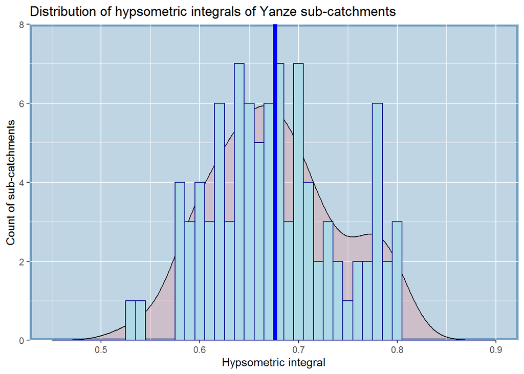

```r
# Generate the summary data
summary_table <- data.frame(x1 = character(),
                     x2 = numeric(),
                     x3 = numeric(),
                     x4 = numeric(),
                     x5 = numeric(),
                     stringsAsFactors = FALSE)
colnames(summary_table)<-c("CODE","MIN_ELEV", "MAX_ELEV", "AREA", "H_INTEGRAL")
 for (i in watersheds){
     if (i < 10)
    n <- paste("C00", i, sep = "")
  else
    n <- paste("C0", i, sep = "")
 CODE <- n
 MIN_ELEV <- all_data[[n]]$minimum
 MAX_ELEV <- all_data[[n]]$maximum
 AREA <- round(sum(all_data[[n]]$data$AREA_GEO),2)
 H_INTEGRAL <- round(all_data[[n]]$h_integral,3)
 summary_table[i,] <- c(CODE, MIN_ELEV, MAX_ELEV, AREA, H_INTEGRAL)
 }
# Produce a summary graph
g <- ggplot(summary_table, aes(x = as.numeric(H_INTEGRAL)))
g <- g + xlim(0.45,0.9)
g <- g + geom_density(alpha=.2, fill="#FF6666")
g <- g + geom_histogram(binwidth = .01, color="darkblue", fill="lightblue")
g <- g + scale_y_continuous(expand = c(0,0), limits = c(0,8))
g <- g + labs(title = "Distribution of hypsometric integrals of Yanze sub-catchments", x = "Hypsometric integral", y = "Count of sub-catchments")
g <- g + geom_vline(aes(xintercept=mean(as.numeric(H_INTEGRAL))),color="blue", size = 2)
g <- g + theme(panel.background = element_rect(fill = "#BFD5E3", colour = "#6D9EC1", size = 2, linetype = "solid"), panel.grid.major = element_line(size = 0.5, linetype = 'solid',colour = "white"), panel.grid.minor = element_line(size = 0.25, linetype = 'solid', colour = "white"))
print(g)
```

The hypsometric analysis showed that all the sub-catchments of Yanze watershed are at young and equilibrium stage with hypsometric integrals ranging from 0.529 to 0.803. This means that all the sub-catchments of Yanze watershed have a potential to undergo intensive erosion if not enough soil conservation measures are undertaken. However, there is still a variability in this potential and this is what we will explore in the next component of this study.

```r
# Print the summary table
kable(summary_table)
```

| CODE | MIN_ELEV | MAX_ELEV | AREA | H_INTEGRAL |
| --- | --- | --- | --- | --- |
| C001 | 1370 | 1667 | 43.7 | 0.695 |
| C002 | 1378 | 1718 | 35.35 | 0.73 |
| C003 | 1394 | 1784 | 23.96 | 0.626 |
| C004 | 1395 | 1805 | 36.51 | 0.615 |
| C005 | 1400 | 1674 | 35.85 | 0.68 |
| C006 | 1410 | 1760 | 60.15 | 0.661 |
| C007 | 1419 | 1810 | 44.85 | 0.589 |
| C008 | 1433 | 1826 | 42.8 | 0.596 |
| C009 | 1428 | 1778 | 50.5 | 0.589 |
| C010 | 1423 | 1760 | 27.47 | 0.644 |
| C011 | 1437 | 1827 | 56.23 | 0.698 |
| C012 | 1451 | 1849 | 48.74 | 0.599 |
| C013 | 1454 | 1890 | 116.83 | 0.671 |
| C014 | 1504 | 1824 | 129.39 | 0.617 |
| C015 | 1534 | 1952 | 95.29 | 0.617 |
| C016 | 1540 | 1934 | 72.25 | 0.698 |
| C017 | 1546 | 1781 | 150.45 | 0.545 |
| C018 | 1556 | 1761 | 54.52 | 0.655 |
| C019 | 1681 | 1996 | 92.08 | 0.648 |
| C020 | 1561 | 2055 | 276.46 | 0.739 |
| C021 | 1565 | 1807 | 58.24 | 0.708 |
| C022 | 1631 | 2071 | 215.4 | 0.681 |
| C023 | 1569 | 1838 | 38.83 | 0.64 |
| C024 | 1571 | 1843 | 65.12 | 0.579 |
| C025 | 1574 | 1855 | 45.82 | 0.579 |
| C026 | 1580 | 1910 | 63.65 | 0.621 |
| C027 | 1584 | 1985 | 103.36 | 0.642 |
| C028 | 1586 | 1968 | 98.3 | 0.645 |
| C029 | 1589 | 1895 | 58.76 | 0.677 |
| C030 | 1594 | 1923 | 55.77 | 0.66 |

[output cut: 63 more lines]